# Tratamiento de valores perdidos con R

Evelyn Gutierrez[^1]

Vilma Romero[^2]

Marzo, 2021

# Introducción.

En esta sesión, realizaremos la imputación de datos perdidos utilizando técnicas básicas y por vecinos más cercanos.

Requerimos instalar los siguientes paquetes:

- `Hmisc`
- `VIM`
- `mice`
- `DMwR`

# Exploración de valores perdidos.

## Caso 1: Notas.

Iniciamos este ejemplo, creando un data.frame notas con alguna nota faltante.

```r
notas <- data.frame(nombre = c("Jesus", "Carla", "Rodrigo", "Javier"),
                    nota = c(12, 15, 13, NA))
notas
```

```
##    nombre nota
## 1   Jesus   12
## 2   Carla   15
## 3 Rodrigo   13
## 4  Javier   NA
```

Finalmente, seleccionar los datos completos con `complete.cases`.

```r
notas_comp <- notas[complete.cases(notas),]
notas_comp
```

```
##    nombre nota
## 1   Jesus   12
## 2   Carla   15
## 3 Rodrigo   13
```

## Caso 2: Dataset sleep

Vamos a utilizar la base de datos sleep del paquete VIM para realizar la exploración de valores perdidos.

Para ello, instalamos el paquete VIM con el siguiente código en la consola: `install.packages("VIM")`.

Luego, cargamos los datos de `sleep` y vemos las primeras filas del dataset utilizando el siguiente código:

```r
data(sleep, package = "VIM")

head(sleep)
```

```
##    BodyWgt BrainWgt NonD Dream Sleep Span Gest Pred Exp Danger
## 1 6654.000   5712.0   NA    NA   3.3 38.6  645    3   5      3
## 2    1.000      6.6  6.3   2.0   8.3  4.5   42    3   1      3
## 3    3.385     44.5   NA    NA  12.5 14.0   60    1   1      1
## 4    0.920      5.7   NA    NA  16.5   NA   25    5   2      3
## 5 2547.000   4603.0  2.1   1.8   3.9 69.0  624    3   5      4
## 6   10.550    179.5  9.1   0.7   9.8 27.0  180    4   4      4
```

Comprobará que el dataset “sleep” ahora aparece también en su environment.

Exploramos este nuevo dataset con los siguientes comandos:

```r
str(sleep)
```

```
## 'data.frame':    62 obs. of  10 variables:
##  $ BodyWgt : num  6654 1 3.38 0.92 2547 ...
##  $ BrainWgt: num  5712 6.6 44.5 5.7 4603 ...
##  $ NonD    : num  NA 6.3 NA NA 2.1 9.1 15.8 5.2 10.9 8.3 ...
##  $ Dream   : num  NA 2 NA NA 1.8 0.7 3.9 1 3.6 1.4 ...
##  $ Sleep   : num  3.3 8.3 12.5 16.5 3.9 9.8 19.7 6.2 14.5 9.7 ...
##  $ Span    : num  38.6 4.5 14 NA 69 27 19 30.4 28 50 ...
##  $ Gest    : num  645 42 60 25 624 180 35 392 63 230 ...
##  $ Pred    : int  3 3 1 5 3 4 1 4 1 1 ...
##  $ Exp     : int  5 1 1 2 5 4 1 5 2 1 ...
##  $ Danger  : int  3 3 1 3 4 4 1 4 1 1 ...
```

```r
dplyr::glimpse(sleep)
```

```
## Rows: 62
## Columns: 10
## $ BodyWgt  <dbl> 6654.000, 1.000, 3.385, 0.920, 2547.000, 10.550, 0.023, 160.~
## $ BrainWgt <dbl> 5712.0, 6.6, 44.5, 5.7, 4603.0, 179.5, 0.3, 169.0, 25.6, 440~
## $ NonD     <dbl> NA, 6.3, NA, NA, 2.1, 9.1, 15.8, 5.2, 10.9, 8.3, 11.0, 3.2, ~
## $ Dream    <dbl> NA, 2.0, NA, NA, 1.8, 0.7, 3.9, 1.0, 3.6, 1.4, 1.5, 0.7, 2.7~
## $ Sleep    <dbl> 3.3, 8.3, 12.5, 16.5, 3.9, 9.8, 19.7, 6.2, 14.5, 9.7, 12.5, ~
## $ Span     <dbl> 38.6, 4.5, 14.0, NA, 69.0, 27.0, 19.0, 30.4, 28.0, 50.0, 7.0~
## $ Gest     <dbl> 645, 42, 60, 25, 624, 180, 35, 392, 63, 230, 112, 281, NA, 3~
## $ Pred     <int> 3, 3, 1, 5, 3, 4, 1, 4, 1, 1, 5, 5, 2, 5, 1, 2, 2, 2, 1, 1, ~
## $ Exp      <int> 5, 1, 1, 2, 5, 4, 1, 5, 2, 1, 4, 5, 1, 5, 1, 2, 2, 2, 2, 1, ~
## $ Danger   <int> 3, 3, 1, 3, 4, 4, 1, 4, 1, 1, 4, 5, 2, 5, 1, 2, 2, 2, 1, 1, ~
```

```r
summary(sleep)
```

```
##     BodyWgt            BrainWgt            NonD            Dream
##  Min.   :   0.005   Min.   :   0.14   Min.   : 2.100   Min.   :0.000
##  1st Qu.:   0.600   1st Qu.:   4.25   1st Qu.: 6.250   1st Qu.:0.900
##  Median :   3.342   Median :  17.25   Median : 8.350   Median :1.800
##  Mean   : 198.790   Mean   : 283.13   Mean   : 8.673   Mean   :1.972
##  3rd Qu.:  48.202   3rd Qu.: 166.00   3rd Qu.:11.000   3rd Qu.:2.550
##  Max.   :6654.000   Max.   :5712.00   Max.   :17.900   Max.   :6.600
##                                       NA's   :14       NA's   :12
##      Sleep            Span              Gest             Pred
##  Min.   : 2.60   Min.   :  2.000   Min.   : 12.00   Min.   :1.000
##  1st Qu.: 8.05   1st Qu.:  6.625   1st Qu.: 35.75   1st Qu.:2.000
##  Median :10.45   Median : 15.100   Median : 79.00   Median :3.000
##  Mean   :10.53   Mean   : 19.878   Mean   :142.35   Mean   :2.871
##  3rd Qu.:13.20   3rd Qu.: 27.750   3rd Qu.:207.50   3rd Qu.:4.000
##  Max.   :19.90   Max.   :100.000   Max.   :645.00   Max.   :5.000
##  NA's   :4       NA's   :4         NA's   :4
##       Exp            Danger
##  Min.   :1.000   Min.   :1.000
##  1st Qu.:1.000   1st Qu.:1.000
##  Median :2.000   Median :2.000
##  Mean   :2.419   Mean   :2.613
##  3rd Qu.:4.000   3rd Qu.:4.000
##  Max.   :5.000   Max.   :5.000
##
```

Exploramos el número de valores perdidos por variable

```r
apply(sleep, 2, function(x){sum(is.na(x))})
```

```
##  BodyWgt BrainWgt     NonD    Dream    Sleep     Span     Gest     Pred
##        0        0       14       12        4        4        4        0
##      Exp   Danger
##        0        0
```

Con esta tabla podemos responder lo siguiente:

- ¿Qué variables tienen valores perdidos?
- ¿Qué variables tienen más valores perdidos?

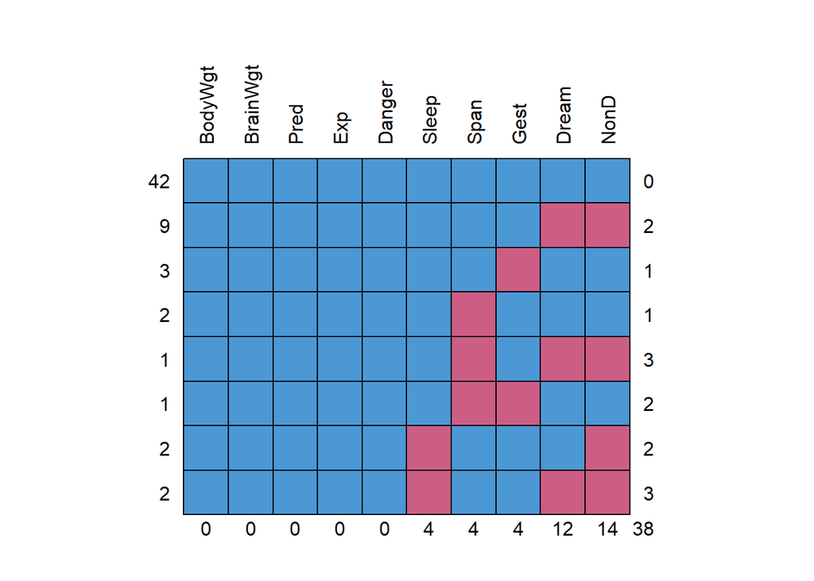

```
##    BodyWgt BrainWgt Pred Exp Danger Sleep Span Gest Dream NonD
## 42       1        1    1   1      1     1    1    1     1    1  0
## 9        1        1    1   1      1     1    1    1     0    0  2
## 3        1        1    1   1      1     1    1    0     1    1  1
## 2        1        1    1   1      1     1    0    1     1    1  1
## 1        1        1    1   1      1     1    0    1     0    0  3
## 1        1        1    1   1      1     1    0    0     1    1  2
## 2        1        1    1   1      1     0    1    1     1    0  2
## 2        1        1    1   1      1     0    1    1     0    0  3
##          0        0    0   0      0     4    4    4    12   14 38
```

```r
mice::md.pattern(sleep, rotate.names=TRUE)
```

```r
mice::md.pairs(sleep)
```

```
## $rr
##          BodyWgt BrainWgt NonD Dream Sleep Span Gest Pred Exp Danger
## BodyWgt       62       62   48    50    58   58   58   62  62     62
## BrainWgt      62       62   48    50    58   58   58   62  62     62
## NonD          48       48   48    48    48   45   44   48  48     48
## Dream         50       50   48    50    48   47   46   50  50     50
## Sleep         58       58   48    48    58   54   54   58  58     58
## Span          58       58   45    47    54   58   55   58  58     58
## Gest          58       58   44    46    54   55   58   58  58     58
## Pred          62       62   48    50    58   58   58   62  62     62
## Exp           62       62   48    50    58   58   58   62  62     62
## Danger        62       62   48    50    58   58   58   62  62     62
##
## $rm
##          BodyWgt BrainWgt NonD Dream Sleep Span Gest Pred Exp Danger
## BodyWgt        0        0   14    12     4    4    4    0   0      0
## BrainWgt       0        0   14    12     4    4    4    0   0      0
## NonD           0        0    0     0     0    3    4    0   0      0
## Dream          0        0    2     0     2    3    4    0   0      0
## Sleep          0        0   10    10     0    4    4    0   0      0
## Span           0        0   13    11     4    0    3    0   0      0
## Gest           0        0   14    12     4    3    0    0   0      0
## Pred           0        0   14    12     4    4    4    0   0      0
## Exp            0        0   14    12     4    4    4    0   0      0
## Danger         0        0   14    12     4    4    4    0   0      0
##
## $mr
##          BodyWgt BrainWgt NonD Dream Sleep Span Gest Pred Exp Danger
## BodyWgt        0        0    0     0     0    0    0    0   0      0
## BrainWgt       0        0    0     0     0    0    0    0   0      0
## NonD          14       14    0     2    10   13   14   14  14     14
## Dream         12       12    0     0    10   11   12   12  12     12
## Sleep          4        4    0     2     0    4    4    4   4      4
## Span           4        4    3     3     4    0    3    4   4      4
## Gest           4        4    4     4     4    3    0    4   4      4
## Pred           0        0    0     0     0    0    0    0   0      0
## Exp            0        0    0     0     0    0    0    0   0      0
## Danger         0        0    0     0     0    0    0    0   0      0
##
## $mm
##          BodyWgt BrainWgt NonD Dream Sleep Span Gest Pred Exp Danger
## BodyWgt        0        0    0     0     0    0    0    0   0      0
## BrainWgt       0        0    0     0     0    0    0    0   0      0
## NonD           0        0   14    12     4    1    0    0   0      0
## Dream          0        0   12    12     2    1    0    0   0      0
## Sleep          0        0    4     2     4    0    0    0   0      0
## Span           0        0    1     1     0    4    1    0   0      0
## Gest           0        0    0     0     0    1    4    0   0      0
## Pred           0        0    0     0     0    0    0    0   0      0
## Exp            0        0    0     0     0    0    0    0   0      0
## Danger         0        0    0     0     0    0    0    0   0      0
```

En estos gráficos y tablas observamos las diferentes combinaciones de valores perdidos que tenemos para nuestras variables. Ahora, podemos responder las siguiente preguntas:

- ¿Cuantas observaciones no tienen nigún valor perdido?
- ¿Cuantas observaciones no tienen nigún valor perdido?

Visualización de datos perdidos

```r
sleep_aggr <- VIM::aggr(sleep, col = mice::mdc(1:2), numbers = TRUE,
                        sortVars = TRUE, labels = names(sleep),
                        cex.axis= 0.7, gap = 3,
                        ylab = c("Proporción de Pérdida",
                                 "Patrón de Pérdida"))
```

[figure not shown]

```
##
##  Variables sorted by number of missings:
##  Variable      Count
##      NonD 0.22580645
##     Dream 0.19354839
##     Sleep 0.06451613
##      Span 0.06451613
##      Gest 0.06451613
##   BodyWgt 0.00000000
##  BrainWgt 0.00000000
##      Pred 0.00000000
##       Exp 0.00000000
##    Danger 0.00000000
```

Distribución de observaciones completas e incompletas por pares de variables

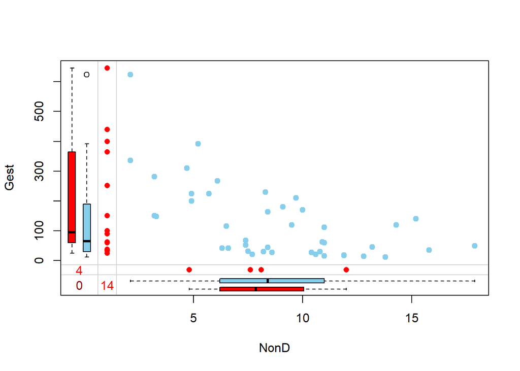

```r
VIM::marginplot(sleep[ , c(3, 7)], pch = 19)
```

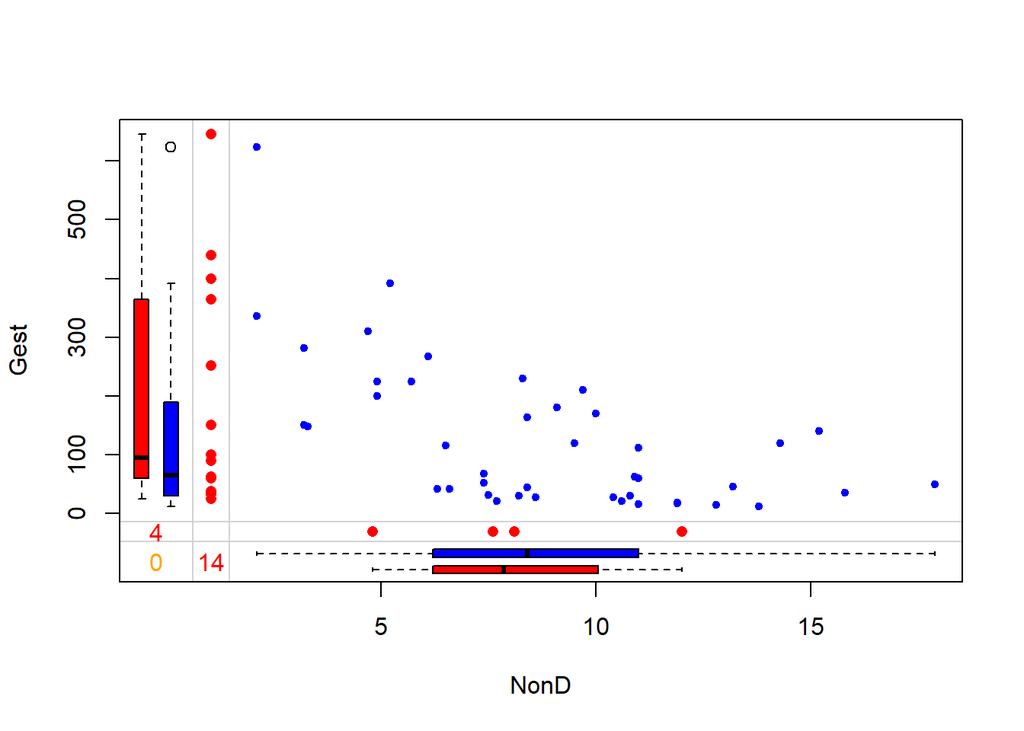

```r
VIM::marginplot(sleep[ , c(3, 7)], col = c("blue", "red", "orange"), pch = 20)
```

Descripción:

- Puntos azules (diagrama de dispersión): individuos con ambos valores de las variables.
- Boxplots azules: boxplots de los valores no perdidos de cada variable
- Puntos rojos (Eje X: NonD): individuos con valores perdidos en Gest pero observados en NonD.
- Puntos rojos (Eje Y: Gest): individuos con valores perdidos en NonD pero observados en Gest.
- Boxplots rojos: Representan la distribución marginal de los puntos rojos.

Nota: Si los datos perdidos son completamente aleatorios se espera que los boxplots rojos y azules sean idénticos

# Imputación Univariada

## Imputación con la media.

instalamos la librería `Hmisc` para realizar imputaciones básicas. La instalación, la realizaremos utilizando el siguiente comando en la consola: `install.packages("Hmisc")`.

Luego de completada la instalación, comprobamos cargando el paquete.

```r
library(Hmisc)
```

Si no tenemos mayor información, utilizaremos la media como valor de imputación. Es una imputación rápida, simple y sencilla.

```r
notas$nota_imp <- with(notas, impute(nota, mean))
notas
```

```
##    nombre nota nota_imp
## 1   Jesus   12 12.00000
## 2   Carla   15 15.00000
## 3 Rodrigo   13 13.00000
## 4  Javier   NA 13.33333
```

## Imputación con valor aleatorio.

Utilizamos un valor aleatorio como valor de imputación.

```r
notas$nota_imp <- with(notas, impute(nota, 'random'))
notas
```

```
##    nombre nota nota_imp
## 1   Jesus   12       12
## 2   Carla   15       15
## 3 Rodrigo   13       13
## 4  Javier   NA       13
```

## Imputación con un valor específico.

Si tenemos información específica, o resulta conveniente, podemos imputar los datos perdidos con un valor específico.

```r
notas$nota_imp <- with(notas, impute(nota, 99))
notas
```

```
##    nombre nota nota_imp
## 1   Jesus   12       12
## 2   Carla   15       15
## 3 Rodrigo   13       13
## 4  Javier   NA       99
```

## Imputación manual

Por ultimo, la imputación puede realizarse sin el paquete Hmisc de la siguiente manera:

```r
notas$nota[is.na(notas$nota)] <- mean(notas$nota, na.rm = T)
notas
```

```
##    nombre     nota nota_imp
## 1   Jesus 12.00000       12
## 2   Carla 15.00000       15
## 3 Rodrigo 13.00000       13
## 4  Javier 13.33333       99
```

# Imputación Multivariada

## Imputación por regresión lineal.

Con la librería mice.

```r
library(mice)
imp <- mice(sleep, method = "norm.predict", m = 1) # Impute data
imp_reg <- complete(imp)
```

Para missings en variables categorícas se puede utilizar regresión logistica con el argumento `method="logreg"`. Para ver otros métodos, podemos ver la documentación de la función mice escribiendo `?mice::mice` en la consola.

## Imputación por el método de K vecinos más cercanos.

Aplicamos vecions más cercanos y guardamos los resultados en sleep_imp

```r
library(DMwR)
sleep_imp <- DMwR::knnImputation(sleep)
#View(sleep_imp)
summary(sleep_imp)
```

```
##     BodyWgt            BrainWgt            NonD            Dream
##  Min.   :   0.005   Min.   :   0.14   Min.   : 2.100   Min.   :0.000
##  1st Qu.:   0.600   1st Qu.:   4.25   1st Qu.: 5.800   1st Qu.:0.925
##  Median :   3.342   Median :  17.25   Median : 8.350   Median :1.800
##  Mean   : 198.790   Mean   : 283.13   Mean   : 8.489   Mean   :1.976
##  3rd Qu.:  48.202   3rd Qu.: 166.00   3rd Qu.:10.757   3rd Qu.:2.567
##  Max.   :6654.000   Max.   :5712.00   Max.   :17.900   Max.   :6.600
##      Sleep            Span              Gest             Pred
##  Min.   : 2.60   Min.   :  2.000   Min.   : 12.00   Min.   :1.000
##  1st Qu.: 6.95   1st Qu.:  6.125   1st Qu.: 35.75   1st Qu.:2.000
##  Median :10.30   Median : 13.350   Median : 65.68   Median :3.000
##  Mean   :10.43   Mean   : 19.133   Mean   :138.65   Mean   :2.871
##  3rd Qu.:13.20   3rd Qu.: 27.000   3rd Qu.:196.80   3rd Qu.:4.000
##  Max.   :19.90   Max.   :100.000   Max.   :645.00   Max.   :5.000
##       Exp            Danger
##  Min.   :1.000   Min.   :1.000
##  1st Qu.:1.000   1st Qu.:1.000
##  Median :2.000   Median :2.000
##  Mean   :2.419   Mean   :2.613
##  3rd Qu.:4.000   3rd Qu.:4.000
##  Max.   :5.000   Max.   :5.000
```

¿Hay datos perdidos ahora?

```r
apply(sleep_imp, 2, function(x){sum(is.na(x))})
```

```
##  BodyWgt BrainWgt     NonD    Dream    Sleep     Span     Gest     Pred
##        0        0        0        0        0        0        0        0
##      Exp   Danger
##        0        0
```

## Imputación por bosques aleatorios.

```r
library(missForest)
sleep_imp_rf <- missForest(sleep)
```

```
##   missForest iteration 1 in progress...done!
##   missForest iteration 2 in progress...done!
##   missForest iteration 3 in progress...done!
##   missForest iteration 4 in progress...done!
```

```r
print(sleep_imp$NonD, digits = 3)
```

```
##  [1]  2.28  6.30 10.28 10.63  2.10  9.10 15.80  5.20 10.90  8.30 11.00  3.20
## [13]  7.60  4.20  6.30  8.60  6.60  9.50  4.80 12.00  4.97  3.30 11.00  8.17
## [25]  4.70 10.54 10.40  7.40  2.10  9.21  7.65  7.70 17.90  6.10  8.20  8.40
## [37] 11.90 10.80 13.80 14.30  5.25 15.20 10.00 11.90  6.50  7.50 10.50 10.60
## [49]  7.40  8.40  5.70  4.90  4.60  3.20  9.66  8.10 11.00  4.90 13.20  9.70
## [61] 12.80 12.04
```

## MICE: Multivariate Imputation by Chained Equations

Utilizaremos la metodología MICE: Multivariate Imputation by Chained Equations para realizar imputación multivariada.

La imputación con MICE puede ser simple o múltiple. Simple si solo se imputa el dataset inicial; y múltiple cuando se crean multiples datasets con diferentes imputaciones.

```r
library(VIM)
library(mice)
```

# Imputación Múltiple

Utilizamos el paquete MICE: Imputación Multivariada por Chained Equations para realizar la imputación múltiple.

```r
library(mice)
```

La imputación se realiza con estas líneas de código:

```r
imp1 <- mice(sleep, m = 5, seed = 2)
imp1
```

```
## Class: mids
## Number of multiple imputations:  5
## Imputation methods:
##  BodyWgt BrainWgt     NonD    Dream    Sleep     Span     Gest     Pred
##       ""       ""    "pmm"    "pmm"    "pmm"    "pmm"    "pmm"       ""
##      Exp   Danger
##       ""       ""
## PredictorMatrix:
##          BodyWgt BrainWgt NonD Dream Sleep Span Gest Pred Exp Danger
## BodyWgt        0        1    1     1     1    1    1    1   1      1
## BrainWgt       1        0    1     1     1    1    1    1   1      1
## NonD           1        1    0     1     1    1    1    1   1      1
## Dream          1        1    1     0     1    1    1    1   1      1
## Sleep          1        1    1     1     0    1    1    1   1      1
## Span           1        1    1     1     1    0    1    1   1      1
## Number of logged events:  11
##   it im  dep meth   out
## 1  1  5 Span  pmm Sleep
## 2  1  5 Gest  pmm Sleep
## 3  3  2 Span  pmm Sleep
## 4  3  5 Span  pmm Sleep
## 5  3  5 Gest  pmm Sleep
## 6  4  1 Span  pmm Sleep
```

El argumento m=5 indica que se crearan 5 datasets de imputaciones.

Verificamos el métodos de imputación utilizado:

```r
imp1$method
```

```
##  BodyWgt BrainWgt     NonD    Dream    Sleep     Span     Gest     Pred
##       ""       ""    "pmm"    "pmm"    "pmm"    "pmm"    "pmm"       ""
##      Exp   Danger
##       ""       ""
```

Como vemos, se usó el método pmm (Predictive mean matching): Un método de imputación semi-parámetrico usado por defecto para variables continuas.

Imputaciones para una variable en particular

```r
head(imp1$imp$NonD)
```

```
##       1    2    3    4    5
## 1   3.2  3.3  2.1  2.1  3.2
## 3  10.0 12.0 10.8 11.9 11.0
## 4  11.0 10.4 12.8 17.9 13.2
## 14  2.1  3.2  3.2  2.1  3.2
## 21 12.8 11.9  7.6  4.7  8.2
## 24  8.4 11.0 11.0 11.0 10.0
```

## Visualización de datos imputados.

Estos gráficos nos servirán para revisar si las imputaciones realizadas son muy variables entre diferentes datasets.

El primer gráfico muestra los valores perdidos para la variable en el eje Y. SE muestran 6 cuadros correspondientes a la data original y los 5 dataset construidos con la imputación multiple. En rojo están las observaciones imputadas para la variable Gest (variable del eje Y); y en azul, todas las demás observaciones. Notese que los puntos azules son los datos observados y además imputaciones realizadas en la variable NonD (variable del eje X).

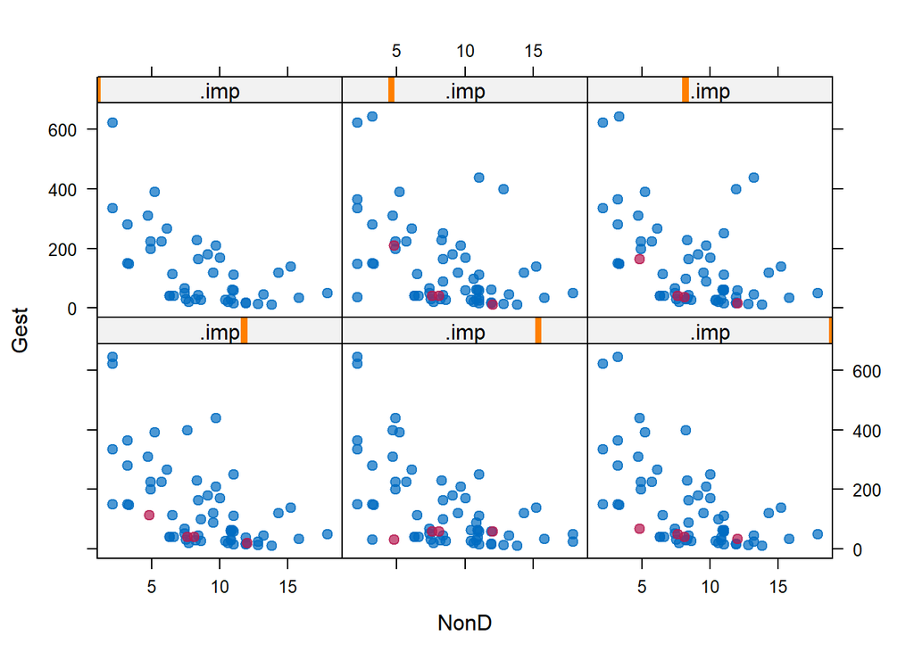

```r
library(lattice)
xyplot(imp1, Gest ~ NonD | .imp, pch = 20, cex = 1.4)
```

En el siguiente gráfico observamos el mismo tipo de digráma. Esta vez enfocado en el análisis de la variable NonD. A partir de los puntos rosados, se observan las variaciones en las imputaciones para NonD en los diferentes datasets contruídos durante la imputación múltiple.

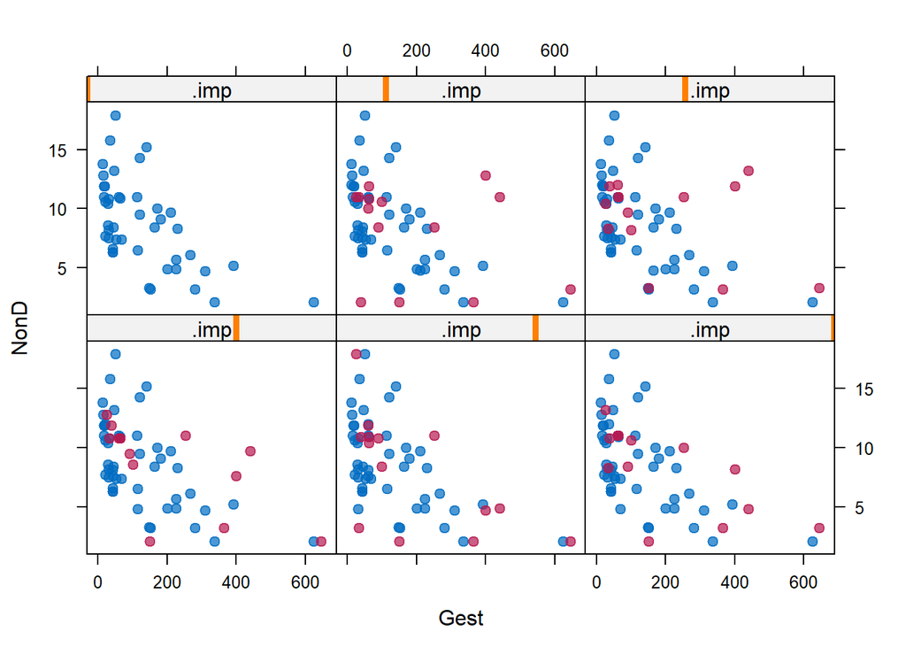

```r
xyplot(imp1, NonD ~ Gest | .imp, pch = 20, cex = 1.4)
```

Finalmente, para observar los datos de las 5 imputaciones en un solo gráfico, tenemos el siguiente código.

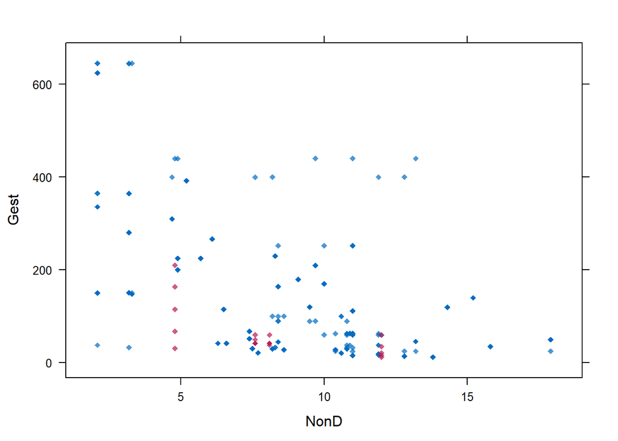

```r
xyplot(imp1, Gest ~ NonD, pch = 18)
```

Y en el caso de querer observa además, la relación de la variable Gest con alguna otra variable adicional, se añade a la variable como el siguiente código.

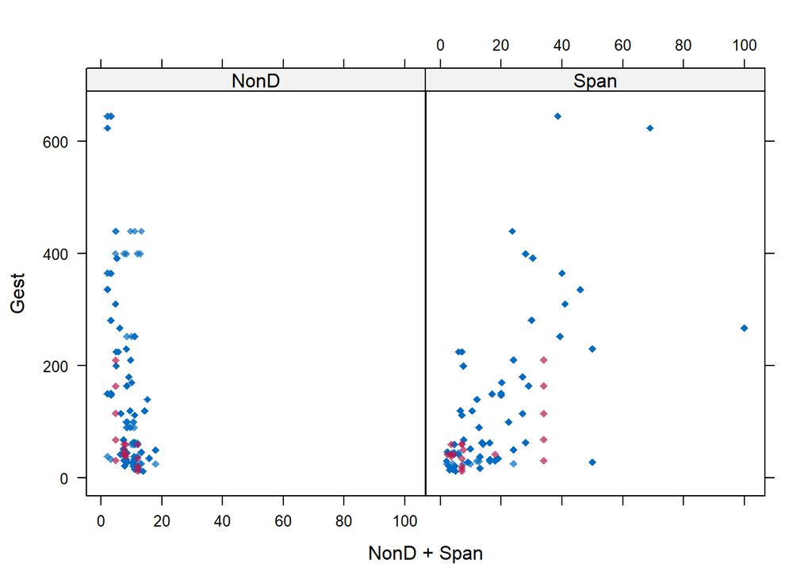

```r
xyplot(imp1, Gest ~ NonD + Span, pch = 18)
```

Finalmente, utilizaremos un gráfico para la densidad de las observaciones imputadas en cada dataset.

Cada densidad en color rosado representa la densidad para las imputaciones en uno de los 5 datasets de la imputación múltiple.

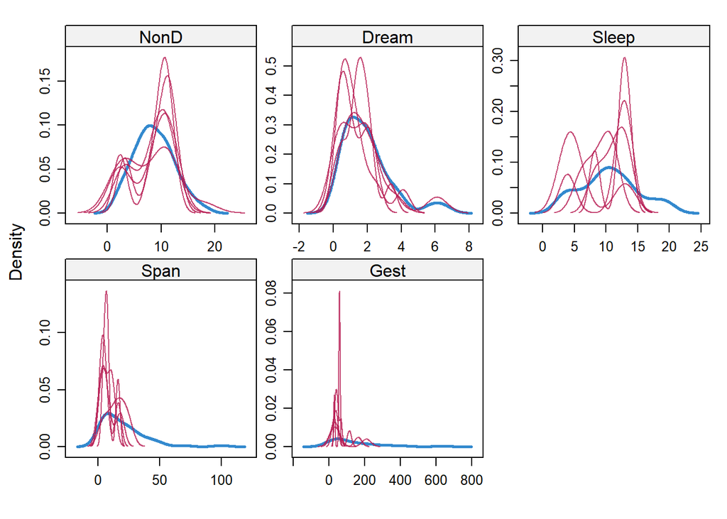

```r
densityplot(imp1)
```

Este gráfico compara la densidad de los datos observados con los datos imputados. Se espera que ambos sean similares (pero no idénticos).

Si encontramos diferencias entre las muestras, esto indica que las imputaciones varian entre diferentes datasets.

El último gráfico llamado stripplot muestra la distribución de cada variable y sus valores imputados en los multiples datasets.

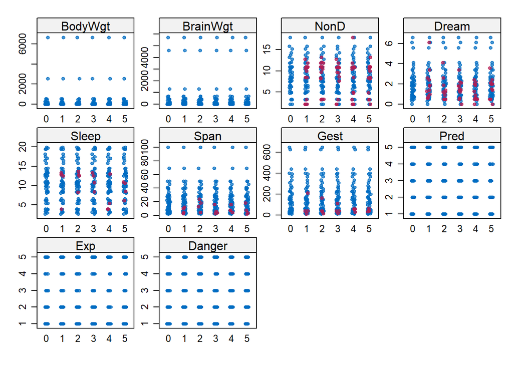

```r
stripplot(imp1, pch = 20)
```

# Modelamiento

## Casos completos

El caso más simple y rápido será utilizando solo los datos completos. En este caso, omitimos las fila con valores perdidos y construimos nuestro modelo.

```r
ajuste_cc <- lm(BodyWgt ~ Sleep + BrainWgt,
                data = na.omit(sleep))
summary(ajuste_cc)
```

```
##
## Call:
## lm(formula = BodyWgt ~ Sleep + BrainWgt, data = na.omit(sleep))
##
## Residuals:
##     Min      1Q  Median      3Q     Max
## -616.89   -4.08   11.32   21.49  244.51
##
## Coefficients:
##             Estimate Std. Error t value Pr(>|t|)
## (Intercept)  8.22805   51.15597   0.161    0.873
## Sleep       -1.98795    4.25534  -0.467    0.643
## BrainWgt     0.52013    0.02735  19.021   <2e-16 ***
## ---
## Signif. codes:  0 '***' 0.001 '**' 0.01 '*' 0.05 '.' 0.1 ' ' 1
##
## Residual standard error: 120.8 on 39 degrees of freedom
## Multiple R-squared:  0.9141, Adjusted R-squared:  0.9097
## F-statistic: 207.6 on 2 and 39 DF,  p-value: < 2.2e-16
```

## Imputación simple.

Despues de una imputación simple, el resultado es un dataset con el mismo número de filas y columna pero con todos los datos llenos con algún valor imputado. Al realizar el modelamiento, se utilizan los resultados de la imputación realizada para entrenar el modelo.

```r
ajuste_cc <- lm(BodyWgt ~ Sleep + BrainWgt, data = imp_reg)
summary(ajuste_cc)
```

```
##
## Call:
## lm(formula = BodyWgt ~ Sleep + BrainWgt, data = imp_reg)
##
## Residuals:
##      Min       1Q   Median       3Q      Max
## -1555.15    12.65    33.54    57.91  1544.48
##
## Coefficients:
##               Estimate Std. Error t value Pr(>|t|)
## (Intercept) -109.62450  115.03832  -0.953    0.345
## Sleep          4.78756    9.67132   0.495    0.622
## BrainWgt       0.91095    0.04766  19.113   <2e-16 ***
## ---
## Signif. codes:  0 '***' 0.001 '**' 0.01 '*' 0.05 '.' 0.1 ' ' 1
##
## Residual standard error: 325.6 on 59 degrees of freedom
## Multiple R-squared:  0.8732, Adjusted R-squared:  0.8689
## F-statistic: 203.1 on 2 and 59 DF,  p-value: < 2.2e-16
```

Nota: Si deseamos utilizar la imputación para nuestra data de validación, tenemos que aplicar la metodología y modelos creados para la imputación a partir de la data de entrenamiento. No deben realizarse modelos para imputaciones con los datos de validación sino podríamos sesgar la evaluación del modelo en la data de entrenamiento.

## Imputación múltiple.

Luego de una imputación multiple, el entrenamiento del modelo debe realizarse en los múltiples datasets imputados.

Multiples modelos serán entrenados a partir de los datasets. Es nuestra tarea evaluar la variabilidad de los modelos en los diferentes conjuntos de datos y analizar el performance conjunto de todo ellos.

Ejemplo: uso de regresión lineal para los múltiples datasets imputados. El resultados del modelo es el siguiente:

```r
ajuste_imp <- with(imp1, lm( BodyWgt ~ Sleep + BrainWgt))
summary(ajuste_imp)
```

```
## # A tibble: 15 x 6
##    term        estimate std.error statistic  p.value  nobs
##    <chr>          <dbl>     <dbl>     <dbl>    <dbl> <int>
##  1 (Intercept) -116.     115.        -1.00  3.20e- 1    62
##  2 Sleep          5.34     9.70       0.550 5.84e- 1    62
##  3 BrainWgt       0.912    0.0476    19.2   5.18e-27    62
##  4 (Intercept) -119.     118.        -1.01  3.16e- 1    62
##  5 Sleep          5.61     9.88       0.568 5.72e- 1    62
##  6 BrainWgt       0.912    0.0478    19.1   6.10e-27    62
##  7 (Intercept) -128.     118.        -1.08  2.86e- 1    62
##  8 Sleep          6.39     9.96       0.642 5.23e- 1    62
##  9 BrainWgt       0.914    0.0480    19.0   7.19e-27    62
## 10 (Intercept) -124.     111.        -1.12  2.69e- 1    62
## 11 Sleep          6.27     9.54       0.657 5.14e- 1    62
## 12 BrainWgt       0.914    0.0478    19.1   5.73e-27    62
## 13 (Intercept) -131.     117.        -1.12  2.68e- 1    62
## 14 Sleep          6.75     9.92       0.680 4.99e- 1    62
## 15 BrainWgt       0.915    0.0480    19.1   6.57e-27    62
```

Note que es posible utilizar cualquier otra función en lugar de `lm()`. El resultado será una lista de modelos para cada dataset.

Finalmente, el análisis de resultados se realizará combinando los resultados de cada modelos. En nuestro caso, se juntan los coeficientes y errores estándares de los 5 modelos de regresión.

```r
ajuste_comb <- pool(ajuste_imp)
summary(ajuste_comb)
```

```
##          term     estimate   std.error  statistic       df   p.value
## 1 (Intercept) -123.4775543 116.1456478 -1.0631268 56.89702 0.2922159
## 2       Sleep    6.0728040   9.8226090  0.6182476 56.84236 0.5388816
## 3    BrainWgt    0.9133712   0.0478443 19.0904921 57.04963 0.0000000
```

```r
pool.r.squared(ajuste_imp)
```

```
##           est     lo 95     hi 95 fmi
## R^2 0.8734907 0.7981373 0.9220335 NaN
```

Estos resultados definen el modelo final a evaluar con la data de validación.

[^1]: egutierreza@pucp.edu.pe
[^2]: vromero@uni.pe